# lecture-11-sample-size-statistical-theory-i

## M303 Sample Size and Statistical Theory I

FALL 2026 · LECTURE 11

M303

Sample Size and Statistical Theory I

Connect representativeness, variability, and precision to sample-size choices.

## Where we are

Fundamentals of Data Analysis

Hypothesis testing

Correlation and regression analysis

Secondary data

Primary data

Observational and Qualitative Methods

Surveys

Sampling

Sampling schemes

Sample size

Problem

Formulation

Research

Design

Data

Collection

Data Analysis &

Recommendation

Preliminary stages of MR

Problem  actionable management problem  research objectives  research questions  hypotheses

Decide on the type of research

Exploratory, descriptive, and causal

## Learning Objectives

You should be able to

Learn factors determining sample size

Learn different ad hoc methods to determine the sample size

Understand differences between parameters and statistics

Learn how to calculate parameters and statistics of central tendency and dispersion

Learn how to calculate confidence intervals for the population mean

Learn how to determine the sample size with statistical techniques

Learn the basic graphical illustrations of data such as bar, pie and line charts

## Previous-class review

01

The process of obtaining information from a subset of a larger group is called sampling.

02

Data about every member of the population is called a census.

03

A list of members of the population from which the sample may be drawn is called sampling unit.

04

If sampling errors are high, it might be better to use a census instead of a sample.

05

If the response quality is important, it might be better to use a census instead of a sample.

06

Errors observed in both census and sample are called sampling errors.

07

You want to survey all IU students, but you only have access to Kelley students. This problem is called the superset problem.

08

In non-probability sampling, every population member has a statistical chance of being in the sample.

09

Non-probability sampling usually gives more representative samples than probability sampling.

## Previous-class review (continued)

Each member of the population has an equal probability to be selected

Simple Random Sampling

Divide population into groups that are different from each other and then select individuals from these groups randomly.

Divide population into similar groups and randomly select these groups.

Stratified Sampling

Cluster Sampling

An experienced individual selects the sample based on his or her judgment about some appropriate characteristics required of the sample members.

Judgment Sampling

Convenient Sampling

Initial respondents are selected by probability methods. Additional respondents are obtained from information provided by the initial respondents.

Snowball Sampling

## Are larger samples always more representative? — Example: Presidential Elections in 1936

1936 U.S. presidential election **The Literary Digest asked millions of people. Gallup used a much smaller sample.**

When the two polls predicted different winners, which result would you trust—and why?

What matters besides the number of people surveyed?

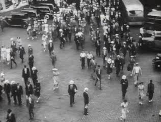

A larger sample is not automatically a better sample.

## Are larger samples always more representative? — Example: Presidential Elections in 1936 (Continued)

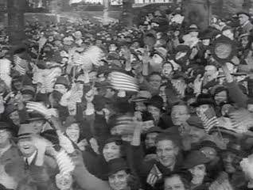

Roosevelt defeated Landon in 1936.

Literary Digest

Millions of mailed-in ballots came from subscription, telephone, and automobile-registration lists. The poll predicted that Roosevelt would lose.

Gallup

A much smaller, more systematically selected sample correctly predicted that Roosevelt would defeat Landon.

A large sample cannot repair a biased selection and response process.

## Which factors determine the sample size?

Number of groups and subgroups within the population

Variability in the population

Value of information for the decision

Accuracy level required in results

Cost of sampling

## Factors Affecting the Sample Size: — Variability in Population

How many drops would you need to learn what is inside a bottle?

[figure not shown]

**Homogeneous population**

Almost any drop resembles the whole. More observations improve precision.

[figure not shown]

**Heterogeneous population**

Different parts contain different information. Sampling from only one region can mislead.

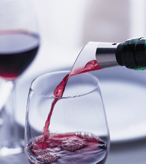

**Sampling design matters**

A larger sample can improve precision, but representativeness depends on covering the population’s variation.

## How do we determine the sample size?

Sample size can be determined either by

Ad hoc methods

Used when a person knows from experience what sample size to adopt

Used when budgetary constraints dictate the size of the sample

Statistical techniques

## Determining sample size: ad hoc methods

Rule of Thumb Method 1

Sample should be large enough, so that when the population divided into groups, each group will have a minimum sample size of 100 or more

Example: Population contains two groups:

Brand Loyals: 20% of the population

Switchers: 80% of the population

Given that, if one wants to use the above rule of thumb method, what should be the minimum sample size under the directly proportional sampling assumption?

## Determining sample size: ad hoc methods (continued)

Rule of Thumb Method 2

In addition to major groups, if you want to compare subgroups in the population, sample size in each subgroup should be 20 to 50

Example: Usage rates of a service by teenagers, young adults, middle-aged and senior people.

Example: If the rule of thumb is to include at least 20 from each subgroup, and the smallest subgroup is 1% of the population, what should be your sample size under directly proportional sampling assumption?

## Determining sample size: ad hoc methods (continued)

Budget Constraints

Especially, if the budget of the project is limited, the sample size might be dictated by budget constraints

Example: You have a $5000 budget for data collection and analysis. You estimate the cost of analysis to be $1000, and the cost of a respondent interview to be $20. What is the maximum affordable sample size for you?

Comparative Studies

Find similar studies and use their sample sizes as a guide

## Statistical Basics - Terminology

Parameters

Measured characteristics of the variables in the population

Lower case Greek letters used as notation

Statistics

Measured characteristics of the variables in the sample

English letters used as notation

[figure not shown]

## How to find/calculate population parameters?

For a variable V in a population, we can calculate parameters of central tendency:

**Population mode** — the most frequent observation

**Population median** — the midpoint: V<sub>(N+1)/2</sub> when N is odd; [V<sub>N/2</sub> + V<sub>N/2+1</sub>]/2 when N is even

**Population mean** — μ = (Σᵢ₌₁ᴺ Vᵢ) / N

Example: For N = 6 midterm grades, V₁ = 78, V₂ = 89, V₃ = 84, V₄ = 86, V₅ = 71, and V₆ = 78. Calculate the population mode, median, and mean.

## How to find/calculate population parameters?

For a variable V in a population, we can calculate parameters of dispersion:

**Population range** — largest observation minus smallest observation

**Population variance** — σ² = [Σᵢ₌₁ᴺ(Vᵢ − μ)²] / N

**Population standard deviation** — σ = √σ²

Example: For N = 6 midterm grades, V₁ = 78, V₂ = 89, V₃ = 84, V₄ = 86, V₅ = 71, and V₆ = 78. Calculate the population range, variance, and standard deviation.

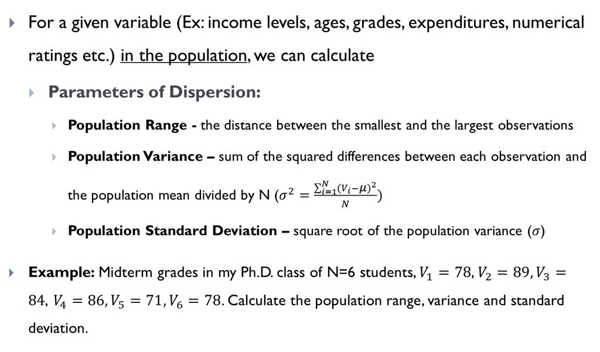

## How to find/calculate sample statistics?

For a variable X in a sample, we can calculate statistics of central tendency:

**Sample mode** — the most frequent observation

**Sample median** — the midpoint: X<sub>(n+1)/2</sub> when n is odd; [X<sub>n/2</sub> + X<sub>n/2+1</sub>]/2 when n is even

**Sample mean** — x̄ = (Σᵢ₌₁ⁿ Xᵢ) / n

## How to find/calculate sample statistics?

For a variable X in a sample, we can calculate statistics of dispersion:

**Sample range** — largest observation minus smallest observation

**Sample variance** — S² = [Σᵢ₌₁ⁿ(Xᵢ − x̄)²] / (n − 1)

**Sample standard deviation** — S = √S²

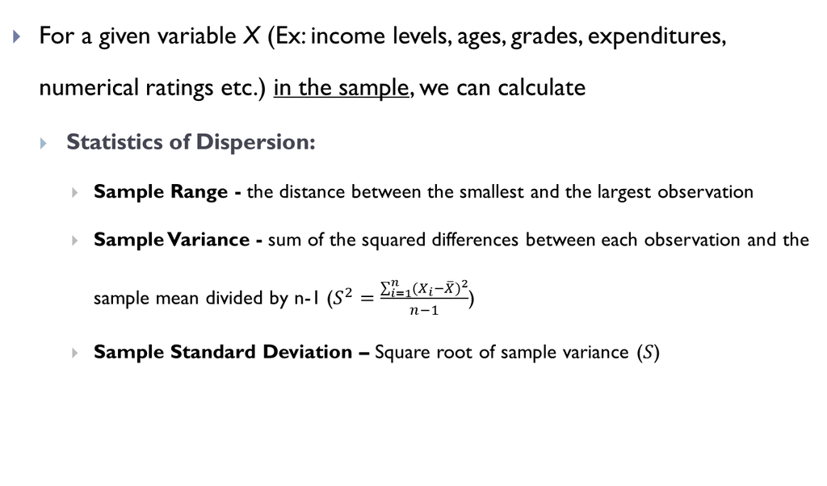

## Example: Calculating/finding sample statistics

Objective: Understand season-ticket holders’ attitudes toward moving weekday symphony performances from 8:00 P.M. to 7:30 P.M.

The population contains 50,000 symphony season-ticket holders.

Question: Do you prefer 7:30 P.M. over 8:00 P.M.?

“Definitely Yes” (coded as +2)

“Yes” (coded as +1)

“Don’t Care” (coded as 0)

“No” (coded as −1)

“Definitely No” (coded as −2)

## Example: Calculating/finding sample statistics (continued)

We ask the previous question in a survey of nine symphony season-ticket holders.

What are the sample mean (x̄), sample variance (S²), and sample standard deviation (S)?

What are the sample median, mode, and range?

William: +2

Elizabeth: 0

Barbara: −2

Michael: +1

Robert: 0

Linda: −1

Patricia: +2

Mary: −1

James: −1

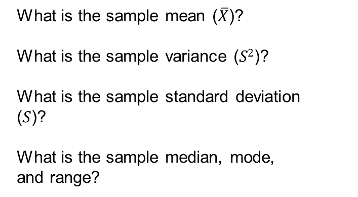

## To sum up

Representativeness depends on how the sample is selected, not only on how large it is.

Population variability, the desired confidence level, and allowable sampling error shape sample-size decisions.

Population parameters describe the population; sample statistics summarize the observed sample.

Measures of central tendency and dispersion prepare us to quantify sampling uncertainty.

## Next class

COMING UP

Sample Size and Statistical Theory II

**Part II**Confidence intervals, statistical sample-size determination, and graphical representations.

**Before class**Check Canvas for current files, reminders, and practice-assignment deadlines.